# Looking at Traits

Going to look at some patterns in traits

```r
library(ggplot2)
library(data.table)
traits <- read.csv("TraitCollectionFishNAtlanticNEPacificContShelf (3).csv")
traits <- data.table(traits)
#remove duplicates
traits.u <- unique(traits, by = c('taxon'))
```

Interested in looking at max age, trophic level, and age of maturity

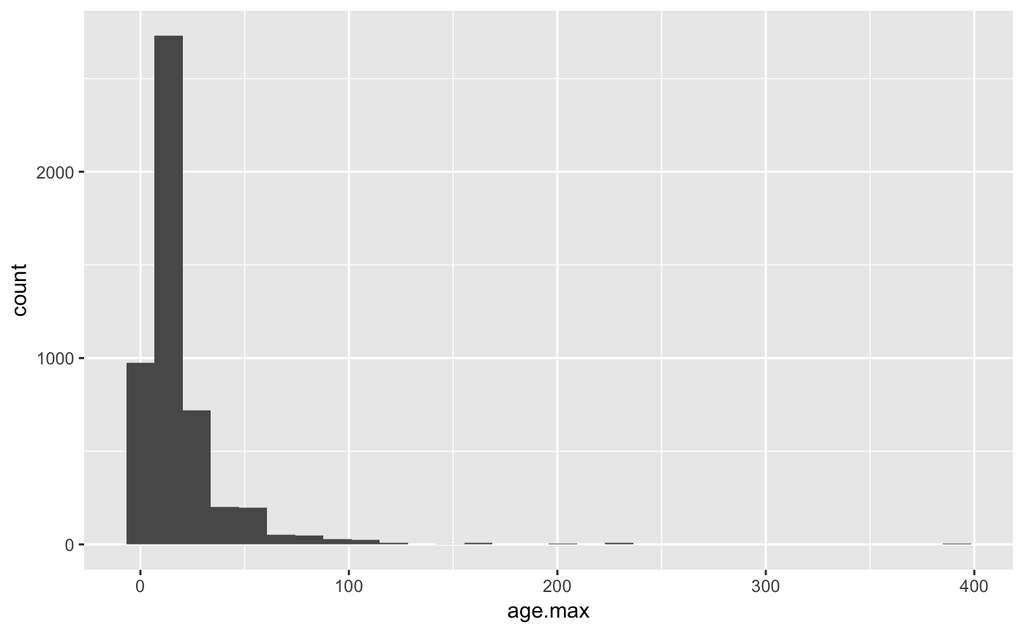

```r
ggplot(aes(x=age.max), data = traits) +
  geom_histogram()
```

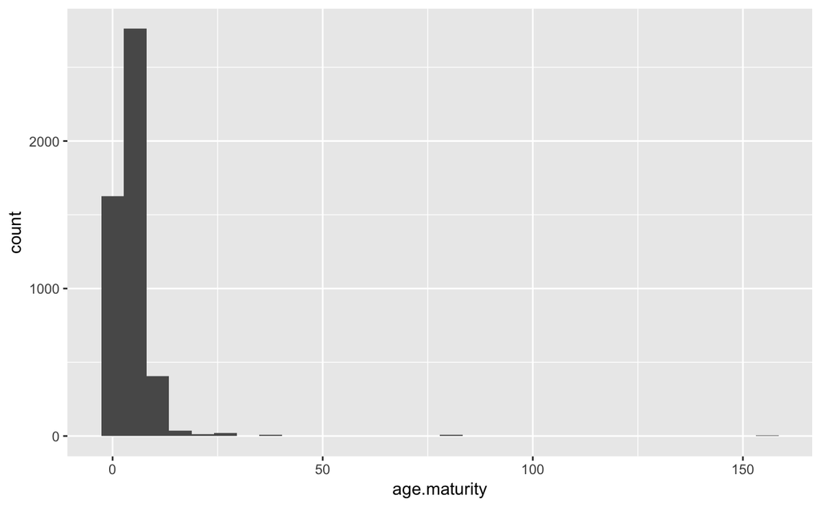

```r
ggplot(aes(x=age.maturity), data = traits) +
  geom_histogram()
```

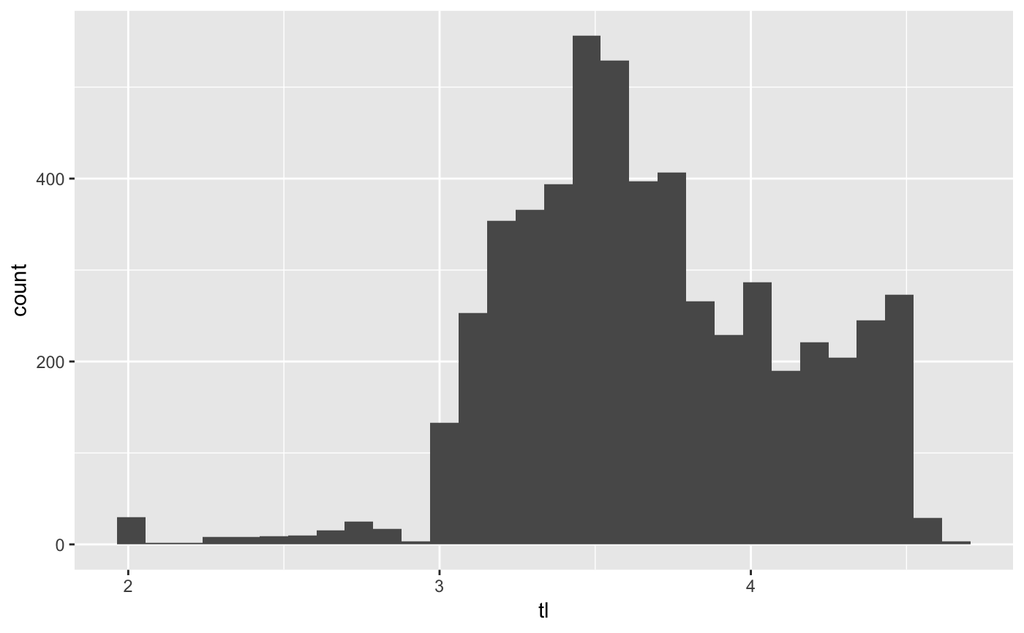

```r
ggplot(aes(x=tl), data = traits) +
  geom_histogram()
```

```r
cor(na.omit(traits[,c(10, 17, 22)]))
```

```
                    tl age.maturity   age.max
tl           1.0000000    0.1749154 0.2154123
age.maturity 0.1749154    1.0000000 0.7285740
age.max      0.2154123    0.7285740 1.0000000
```

They have a R^2 value of 0.53, so, worth it to try both.

Let’s link species

First, let’s see if there are any errors?

```r
load("spp_master_ztemp_seus_buoys.Rdata")
spp_master_spp <- data.frame(spp = unique(spp_master_ztemp_seus_buoy$spp), origin = "spp_master")
traits_spp <- data.frame(spp = unique(traits$taxon), origin = "traits")
spp_all <- rbind(spp_master_spp, traits_spp)
spp_all$spp <- as.character(spp_all$spp)
spp_all.u <- spp_all[!duplicated(spp_all$spp),]
```

# Species to fix

species | location

Arctozenus risso | spp_master Arctozenus risso kroyeri | spp_master *Arctozenus risso in traits, so best to apply same to both Arctozenus and Artozenus risso kroyeri in spp_master

```r
row <- traits.u[taxon == "Arctozenus risso",]
row[,taxon := "Arctozenus risso kroyeri"][, species := "risso kroyeri"]
traits.u <- rbind(traits.u, row)
```

Myoxocephalus scorpioides | spp_master Myoxocephalus scorpius | spp_master *yes, these are different!

Auxis rochei rochei | traits *ignore, not in our hauls

Diplecogaster bimaculata | traits Diplecogaster bimaculata bimaculata | traits *ignore, not in our hauls

Etrumeus teres | traits Etrumeus teres(sadina) | spp_master *change spp_master to Etrumeus teres

```r
spp_master_ztemp_seus_buoy[spp == "Etrumeus teres(sadina)", spp := "Etrumeus teres"]
```

Eualus gaimardii gaimardii | spp_master *ignore, not in trait database

Gasterosteus aculeatus | traits Gasterosteus aculeatus williamsoni | traits *ignore, not in our hauls

Lestidiops jayakari | traits Lestidiops jayakari jayakari | traits *ignore, not in our hauls

Liparis liparis liparis | traits *ignore, not in our hauls

Macroramphosus scolopax | traits Macrorhamphosus scolopax | spp_master *spelling error in spp_master, change to Macroramphosus scolopax

```r
spp_master_ztemp_seus_buoy[spp == "Macrorhamphosus scolopax", spp := "Macroramphosus scolopax"]
```

Mullus barbatus barbatus | traits *ignore, not in our hauls

Myliobatis freminvillei | traits Myliobatis freminvillii | spp_master *spelling error in spp_master, change to Myliobatis freminvillei

```r
spp_master_ztemp_seus_buoy[spp == "Myliobatis freminvillii", spp := "Myliobatis freminvillei"]
```

Nicholsina usta usta | traits *ignore, not in our hauls

Notoscopelus elongatus kroyeri | traits *ignore, not in our hauls

Oxyporhamphus micropterus micropterus | traits *ignore, not in our hauls

Polydactylus octoemus | spp_master Polydactylus octonemus | traits *spelling error in spp_master, change to Polydactylus octonemus

```r
spp_master_ztemp_seus_buoy[spp == "Polydactylus octoemus", spp := "Polydactylus octonemus"]
```

Salmo trutta trutta | traits *ignore, not in our hauls

Scomberesox saurus saurus | traits *ignore, not in our hauls

Stichaeus punctatus | spp_master Stichaeus punctatus punctatus | traits *delte one punctatus from traits

```r
traits.u[taxon == "Stichaeus punctatus punctatus", taxon := "Stichaeus punctatus"][species == "punctatus punctatus", species := "punctatus"]
```

Stomias boa boa | traits Stomias boa ferox | traits *ignore, not in our trawls

Symphurus civitatium | traits Symphurus civitatum | spp_master *spelling error in spp_master, change to Symphurus civitatium

```r
spp_master_ztemp_seus_buoy[spp == "Symphurus civitatum", spp := "Symphurus civitatium"]
```

Zenopsis conchifer | traits Zenopsis conchifera | spp_master *spelling error in spp_master, change to Zenopsis conchifer

```r
spp_master_ztemp_seus_buoy[spp == "Zenopsis conchifera", spp := "Zenopsis conchifer"]
```

Okay, now we can go forward. Let’s link traits to spp_master with temp data

```r
traits.u[, spp := taxon][, taxon := NULL]
spp_master_ztemp_seus_buoy.traits <- spp_master_ztemp_seus_buoy[traits.u, nomatch = 0, on = c("spp")]
```

Now to save updated data.table with traits for species we have traits for

```r
save(spp_master_ztemp_seus_buoy.traits, file = "spp_master_ztemp_seus_buoy.traits.Rdata")
```

Now, what happens if we add traits to our models?

Let’s just look at our best models

Colonization

max_sbt_temp_change_abs 0.23859896 4.768169e-06 6878.288

```r
#First, how does this model do with only rows that we actually have trait data for?
spp_master_ztemp_seus_buoy.traits.na.age.max <- na.omit(spp_master_ztemp_seus_buoy.traits, cols="age.max")
spp_master_ztemp_seus_buoy.traits.na.age.max[,year_factor := as.factor(year)]
```

Does it hold up with this limited data set? Now, I need to run all models again with this restricted data set

```r
#going to make loop to make all models I need to look at with single SURFACE variables
surface_variables <- colnames(spp_master_ztemp_seus_buoy.traits.na.age.max[,45:168])
surface_colonization_model_comparison.maxage <- as.data.table(matrix(nrow = length(surface_variables)))
surface_colonization_model_comparison.maxage[, variable:=as.factor(V1)][, coef:=as.numeric(V1)][, p_value:=as.numeric(V1)][, AICc:=as.numeric(V1)]
surface_colonization_model_comparison.maxage[, V1 := NULL]
for (i in 1:length(surface_variables)){
  mod <- glmer(col ~ get(surface_variables[i]) + (1|reg) + (1|year_factor), family = binomial, data = spp_master_ztemp_seus_buoy.traits.na.age.max)
  surface_colonization_model_comparison.maxage[i,variable := surface_variables[i]]
  surface_colonization_model_comparison.maxage[i,coef := coef(summary(mod))[,"Estimate"][2]]
  surface_colonization_model_comparison.maxage[i,p_value := coef(summary(mod))[,"Pr(>|z|)"][2]]
  surface_colonization_model_comparison.maxage[i,AICc := AICc(mod)]

  print(paste(i, length(surface_variables), sep = "/"))

}
```

```
[1] "1/124"
[1] "2/124"
```

```
Model failed to converge with max|grad| = 0.00108993 (tol = 0.001, component 1)
```

[output not shown]

[output cut: 30 more lines]

This is telling me that previous best model (max sbt temp change abs) is still good, but not the best… Therefore, it seems like we shoould be ignoring traits for now. Future analyses…

Extinction

seas_sbt_temp_change_abs_lag9 0.16783102 0.002379916 6207.213  
min_sst_temp_change_lag2 -0.09468652 0.010582502 6209.860  
min_sbt_temp_change_lag7 -0.11564632 0.010589365 6210.022

NEXT STEPS Can we make a plot for how likelihood of colonization and extinction changes with age.max?

Age of Maturity for Colonization

Let’s look at some other traits maybe? Trophic level? (tl)

Colonization Trophic Level

Split by region? build individual models in regions? or make different plots for different regions?

Age at maturity

```r
spp_master_ztemp_seus_buoy.traits.na.age.maturity <- na.omit(spp_master_ztemp_seus_buoy.traits, cols="age.maturity")
 #to do
```